# 2 Field sites

```r
library(grassland)
theme_set(ggthemes::theme_few())
```

Tidy up and correct community composition data (experimental and observational).

```r
path_community_tidy <- tidy_community_data()
```

```r
dat_community_tidy <- read_community(version = "tidy")
```

Read site information.

```r
read_site_info() %>% knitr::kable()
```

| site | site_name | grass_type | data_method | geometry |
| --- | --- | --- | --- | --- |
| angelo | Angelo Coast | Coastal prairie | Cover in 30×0.09-m2 quadrats | POINT (-123.6531 39.71736) |
| carrizo | Carrizo Plain | Valley | 9×9 point-intercepts in 1-m2 quadrats, first species hit | POINT (-119.8626 35.18906) |
| elkhorn | Elkhorn Slough | Coastal prairie | 5×5 point-intercepts in 0.25-m2 quadrats; each species recorded only once at each sample point | POINT (-121.741 36.86733) |
| jasper | Jasper Ridge | Serpentine | Cover in 1-m2 quadrats | POINT (-122.2422 37.40622) |
| jrgce | Jasper Ridge Global Change Experiment | Valley | Point intercept | POINT (-122.2422 37.40622) |
| mclann | McLaughlin Annual | Valley | Cover in 1-m2 quadrats | POINT (-122.421 38.86978) |
| mclserp | McLaughlin Serpentine | Serpentine | Cover in 1-m2 quadrats | POINT (-122.421 38.86978) |
| morganterritory | Morgan Territory | Valley | 70 point-intercepts along four 17-m transects; tallest species only | POINT (-121.7959 37.81831) |
| pleasantonridge | Pleasanton Ridge | Valley | 70 point-intercepts along four 17-m transects; tallest species only | POINT (-121.8846 37.61541) |
| scide | IDE Arboretum | Coastal prairie | Cover in 4-m2 plots | POINT (-122.0523 36.97746) |
| scide | IDE Marshall Field | Coastal prairie | Cover in 4-m2 plots | POINT (-122.0792 37.01583) |
| scide | IDE Younger Lagoon | Coastal prairie | Cover in 4-m2 plots | POINT (-122.0667 36.95) |
| sunol | Sunol | Valley | 70 point-intercepts along four 17-m transects; tallest species only | POINT (-121.8286 37.51018) |
| swanton | Swanton Ranch | Coastal prairie | 5×5 point-intercepts in 0.25-m2 quadrats; each species recorded only once at each sample point | POINT (-122.2211 37.04531) |
| ucsc | UC Santa Cruz | Coastal prairie | 5×5 point-intercepts in 0.25-m2 quadrats; each species recorded only once at each sample point | POINT (-122.0526 36.98642) |
| vascocaves | Vasco Caves | Valley | 70 point-intercepts along four 17-m transects; tallest species only | POINT (-121.687 37.805) |

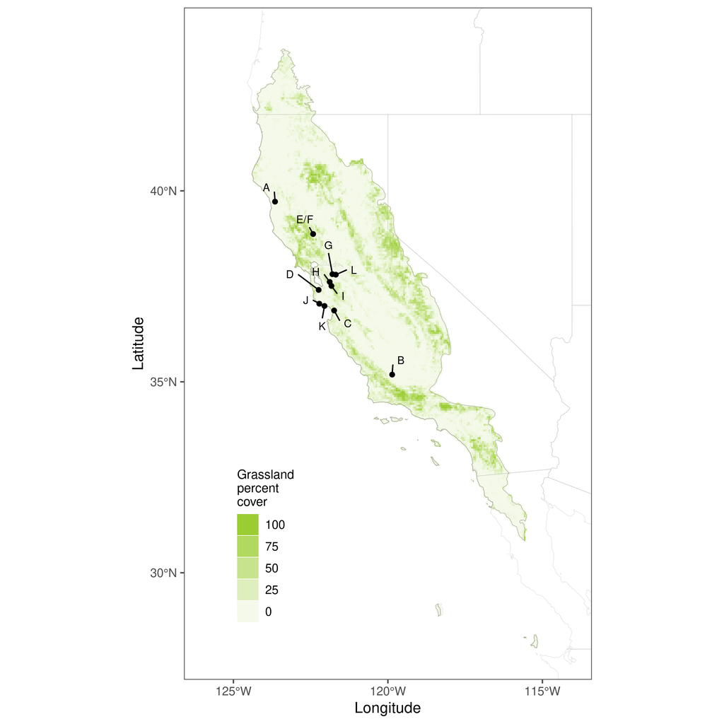

```r
gg_site_map <- plot_site_map()
gg_site_map
```

Visualize data availability across sites.

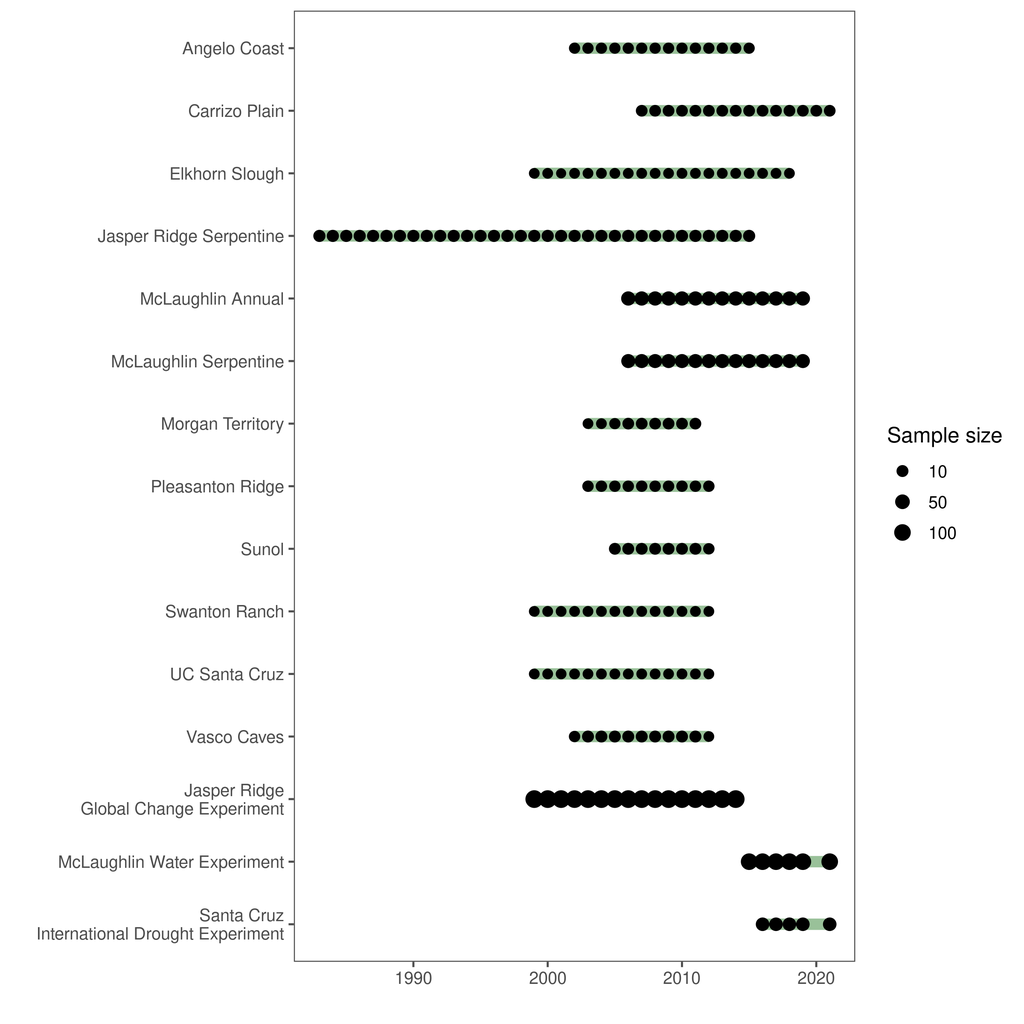

```r
df_data_avail <- summ_data_avail(dat_community, type = "long")
gg_data_avail <- plot_data_availability(df_data_avail)
gg_data_avail
```

```r
df_data_avail_obs <- summ_data_avail(dat_community, type = "short", subset = "obs")
```

We compiled 8 - 33 yr observational data from 12 sites with 176 total site years.

Summarize the geographic and climatic extents of the study sites.

```r
sf_site_obs <- read_site_info(subset = "obs")
dat_clim <- read_climate()
df_summ_site_latlon <- summ_site_obs(sf_site = sf_site_obs, dat_clim = dat_clim$chelsa, type = "latlon")
df_summ_site_clim <- summ_site_obs(sf_site = sf_site_obs, dat_clim = dat_clim$chelsa, type = "climate")
summ_site_hull <- summ_site_obs(sf_site = sf_site_obs, dat_clim = dat_clim$chelsa, type = "hull")
```

These observational sites spanned a large geographical area (120 - 124 °W, 35.2 - 39.7 °N) and climate gradient (12.8 - 17 °C temperature, 255 - 1840 mm precipitation).

These observational sites spanned an approximately 30,000 km<sup>2</sup> geographical area.

```r
path_climate_site_annual <- calc_climate_annual_site()
```

Calculate and summarize climate change at these observational sites.

```r
dat_clim_site <- read_climate_site()
df_cc_site <- calc_climate_change_site(dat_clim_site = dat_clim_site)
df_cc_site %>%
  mutate(
    estimate = estimate %>% signif(3),
    std.error = std.error %>% signif(3),
    p.value = p.value %>% round(4)
  ) %>%
  knitr::kable()
```

| site | clim_var | estimate | std.error | p.value | sig |
| --- | --- | --- | --- | --- | --- |
| all | tmp | 0.01770 | 0.00208 | 0.0000 | *** |
| all | ppt | -4.22000 | 1.05000 | 0.0001 | *** |
| angelo | tmp | 0.00531 | 0.00672 | 0.4345 | ns |
| angelo | ppt | -15.10000 | 6.97000 | 0.0363 | * |
| carrizo | tmp | 0.02450 | 0.00775 | 0.0030 | ** |
| carrizo | ppt | -1.54000 | 1.32000 | 0.2510 | ns |
| elkhorn | tmp | 0.01310 | 0.00716 | 0.0758 | ns |
| elkhorn | ppt | -2.32000 | 2.29000 | 0.3170 | ns |
| jasper | tmp | 0.01510 | 0.00758 | 0.0530 | ns |
| jasper | ppt | -5.89000 | 3.47000 | 0.0978 | ns |
| mclann | tmp | 0.01830 | 0.00753 | 0.0195 | * |
| mclann | ppt | -4.16000 | 4.48000 | 0.3585 | ns |
| mclserp | tmp | 0.01830 | 0.00753 | 0.0195 | * |
| mclserp | ppt | -4.16000 | 4.48000 | 0.3585 | ns |
| morganterritory | tmp | 0.02430 | 0.00647 | 0.0006 | *** |
| morganterritory | ppt | -0.70800 | 2.32000 | 0.7622 | ns |
| pleasantonridge | tmp | 0.02360 | 0.00719 | 0.0022 | ** |
| pleasantonridge | ppt | -1.96000 | 2.19000 | 0.3756 | ns |
| sunol | tmp | 0.02600 | 0.00771 | 0.0017 | ** |
| sunol | ppt | -2.54000 | 2.36000 | 0.2886 | ns |
| swanton | tmp | 0.00846 | 0.00729 | 0.2527 | ns |
| swanton | ppt | -6.17000 | 3.77000 | 0.1095 | ns |
| ucsc | tmp | 0.00792 | 0.00645 | 0.2272 | ns |
| ucsc | ppt | -5.74000 | 3.96000 | 0.1547 | ns |
| vascocaves | tmp | 0.02780 | 0.00664 | 0.0002 | *** |
| vascocaves | ppt | -0.32600 | 2.08000 | 0.8764 | ns |

```r
df_summ_site_cc <- summ_change(df_change = df_cc_site, option = "obs")
df_summ_site_cc
```

```
#> # A tibble: 2 × 6
#>   clim_var     n n_sig    mean       min     max
#>   <fct>    <int> <int>   <dbl>     <dbl>   <dbl>
#> 1 tmp         12     7  0.0177   0.00531  0.0278
#> 2 ppt         12     1 -4.22   -15.1     -0.326
```

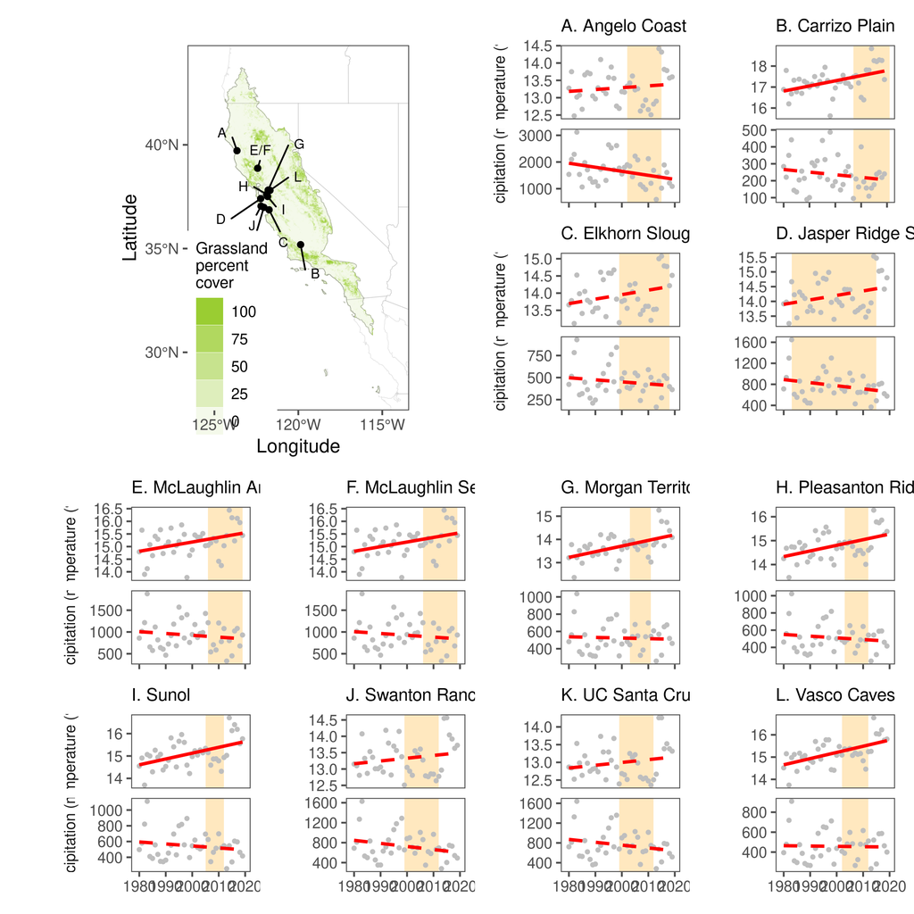

```r
gg_site_cc <- plot_site_climate_change(dat_clim_site = dat_clim_site, dat_avail = df_data_avail)
gg_site_cc
```

```r
gg_site_cc_landsc <- plot_site_climate_change(dat_clim_site = dat_clim_site, dat_avail = df_data_avail, layout = "landsc", nrow = 2)
```

Overall, the 12 observational sites had significant warming (0.0177 °C yr<sup>-1</sup>) and significant drying (4.22 mm yr<sup>-1</sup>) over the years.

Likewise, summarize climate information at the experimental site.

```r
df_data_avail_exp <- summ_data_avail(dat_community, type = "long", subset = "exp")
df_jrgce_env <- read_jrgce_env()
df_summ_jrgce_env <- summ_jrgce_env(df_env = df_jrgce_env)
```

The experiment occupied ~0.75 ha within a 5-ha grassland stand and experienced a large variation of plot-level temperature (8.69 - 12.3 °C) and precipitation (240 - 1380 mm) in 2174 total plot years.

Output figures and R data files.

```r
save_figure(out = list(
  site_map = gg_site_map,
  data_avail = gg_data_avail,
  site_cc = gg_site_cc,
  site_cc_landsc = gg_site_cc_landsc
))

save_extdata(out = list("alldata/input/basemap/site_info.csv"))
```